# DADA2 + PacBio: Fecal Samples

Benjamin J Callahan

## Data

The data were processed from extracted gDNA by PacBio using their 16S protocol and the Sequel sequencing instrument. Replicate 1 was sequenced using the S/P2-C2/5.0 sequencing chemistry, and Replicate 2 was sequenced with a pre-release version of the S/P3-C3/5.0 sequencing chemistry.

CCS reads were constructed using PacBio’s software, default parameters (including `minPasses` of 3) and a `minPredictedAccuracy` of 99.9%.

## Setup

Load libraries, setup paths, prepare environment:

```r
library(dada2);packageVersion("dada2")
```

```
## [1] '1.12.1'
```

```r
library(Biostrings); packageVersion("Biostrings")
```

```
## [1] '2.46.0'
```

```r
library(ShortRead); packageVersion("ShortRead")
```

```
## [1] '1.36.1'
```

```r
library(ggplot2); packageVersion("ggplot2")
```

```
## [1] '3.1.0'
```

```r
library(reshape2); packageVersion("reshape2")
```

```
## [1] '1.4.3'
```

```r
library(gridExtra); packageVersion("gridExtra")
```

```
## [1] '2.3'
```

```r
library(phyloseq); packageVersion("phyloseq")
```

```
## [1] '1.25.2'
```

```r
path1 <- "~/Desktop/LRAS/Data/Fecal1" # CHANGE ME to location of the First Replicate fastq files
path2 <- "~/Desktop/LRAS/Data/Fecal2" # CHANGE ME to location of the Second Replicate fastq files
path.out <- "Figures/"
path.rds <- "RDS/"
fns1 <- list.files(path1, pattern="fastq.gz", full.names=TRUE)
fns2 <- list.files(path2, pattern="fastq.gz", full.names=TRUE)
F27 <- "AGRGTTYGATYMTGGCTCAG"
R1492 <- "RGYTACCTTGTTACGACTT"
rc <- dada2:::rc
theme_set(theme_bw())
```

## Process Replicate 2

We will start by processing replicate 2, the high depth replicate, which we will use to explore the *E. coli* ASVs in this data.

## Remove Primers and Filter

Remove primers and orient reads:

```r
nops2 <- file.path(path2, "noprimers", basename(fns2))
prim2 <- removePrimers(fns2, nops2, primer.fwd=F27, primer.rev=dada2:::rc(R1492), orient=TRUE)
```

Higher loss here than in the mock communities, but still very reasonable. Probably not surprising its a bit higher given this is a real sample rather than mock DNA, and the DNA extraction step was done by CoreBiome without special care to ensuring higher molecular weight DNA.

Inspect length distribution.

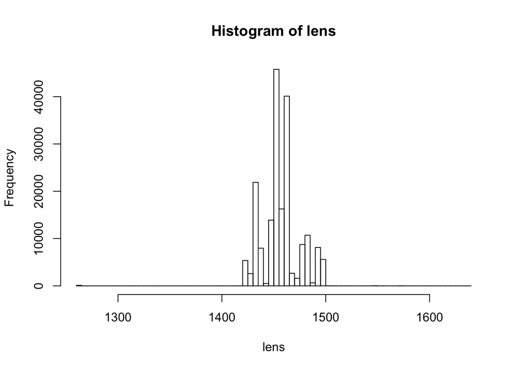

```r
lens.fn <- lapply(nops2, function(fn) nchar(getSequences(fn)))
lens <- do.call(c, lens.fn)
hist(lens, 100)
```

Very strong peak ~1450, looks good.

Filter:

```r
filts2 <- file.path(path2, "noprimers", "filtered", basename(fns2))
track2 <- filterAndTrim(nops2, filts2, minQ=3, minLen=1000, maxLen=1600, maxN=0, rm.phix=FALSE, maxEE=2)
track2
```

```
##                                      reads.in reads.out
## Callahan_16S_R_11.1.ccs99.9.fastq.gz    17436     17147
## Callahan_16S_R_3.1.ccs99.9.fastq.gz     26605     26190
## Callahan_16S_R_3.2.ccs99.9.fastq.gz     24477     24081
## Callahan_16S_R_3.3.ccs99.9.fastq.gz     16738     16474
## Callahan_16S_R_9.1.ccs99.9.fastq.gz     28623     28171
## Callahan_16S_R_9.1B.ccs99.9.fastq.gz    24832     24453
## Callahan_16S_R_9.2.ccs99.9.fastq.gz     21759     21411
## Callahan_16S_R_9.3.ccs99.9.fastq.gz     18701     18429
## Callahan_16S_R_9.4.ccs99.9.fastq.gz     13481     13258
```

Losing <2% of reads per sample. Mean/Median reads per sample is over 20K! No low depth outliers.

## Run DADA2

Dereplicate:

```r
drp2 <- derepFastq(filts2, verbose=TRUE)
```

```
## Dereplicating sequence entries in Fastq file: ~/Desktop/LRAS/Data/Fecal2/noprimers/filtered/Callahan_16S_R_11.1.ccs99.9.fastq.gz
```

```
## Encountered 4468 unique sequences from 17147 total sequences read.
```

```
## Dereplicating sequence entries in Fastq file: ~/Desktop/LRAS/Data/Fecal2/noprimers/filtered/Callahan_16S_R_3.1.ccs99.9.fastq.gz
```

```
## Encountered 4958 unique sequences from 26190 total sequences read.
```

```
## Dereplicating sequence entries in Fastq file: ~/Desktop/LRAS/Data/Fecal2/noprimers/filtered/Callahan_16S_R_3.2.ccs99.9.fastq.gz
```

```
## Encountered 5326 unique sequences from 24081 total sequences read.
```

```
## Dereplicating sequence entries in Fastq file: ~/Desktop/LRAS/Data/Fecal2/noprimers/filtered/Callahan_16S_R_3.3.ccs99.9.fastq.gz
```

```
## Encountered 3668 unique sequences from 16474 total sequences read.
```

```
## Dereplicating sequence entries in Fastq file: ~/Desktop/LRAS/Data/Fecal2/noprimers/filtered/Callahan_16S_R_9.1.ccs99.9.fastq.gz
```

```
## Encountered 6385 unique sequences from 28171 total sequences read.
```

```
## Dereplicating sequence entries in Fastq file: ~/Desktop/LRAS/Data/Fecal2/noprimers/filtered/Callahan_16S_R_9.1B.ccs99.9.fastq.gz
```

```
## Encountered 5529 unique sequences from 24453 total sequences read.
```

```
## Dereplicating sequence entries in Fastq file: ~/Desktop/LRAS/Data/Fecal2/noprimers/filtered/Callahan_16S_R_9.2.ccs99.9.fastq.gz
```

```
## Encountered 5519 unique sequences from 21411 total sequences read.
```

```
## Dereplicating sequence entries in Fastq file: ~/Desktop/LRAS/Data/Fecal2/noprimers/filtered/Callahan_16S_R_9.3.ccs99.9.fastq.gz
```

```
## Encountered 5152 unique sequences from 18429 total sequences read.
```

```
## Dereplicating sequence entries in Fastq file: ~/Desktop/LRAS/Data/Fecal2/noprimers/filtered/Callahan_16S_R_9.4.ccs99.9.fastq.gz
```

```
## Encountered 3772 unique sequences from 13258 total sequences read.
```

Roughly 1/4th unique sequences in these samples.

Learn errors:

```r
err2 <- learnErrors(drp2, errorEstimationFunction=PacBioErrfun, BAND_SIZE=32, multithread=TRUE)
```

```
## 122486022 total bases in 83892 reads from 4 samples will be used for learning the error rates.
```

```r
saveRDS(err2, file.path(path.rds, "Fecal_err2.rds"))
```

Inspect errors:

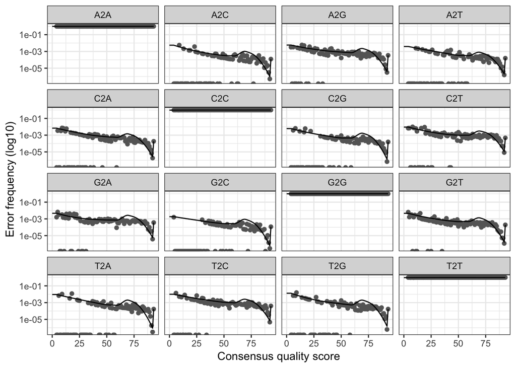

```r
plotErrors(err2)
```

Looks good.

Denoise:

```r
dd2 <- dada(drp2, err=err2, BAND_SIZE=32, multithread=TRUE)
```

```
## Sample 1 - 17147 reads in 4468 unique sequences.
## Sample 2 - 26190 reads in 4958 unique sequences.
## Sample 3 - 24081 reads in 5326 unique sequences.
## Sample 4 - 16474 reads in 3668 unique sequences.
## Sample 5 - 28171 reads in 6385 unique sequences.
## Sample 6 - 24453 reads in 5529 unique sequences.
## Sample 7 - 21411 reads in 5519 unique sequences.
## Sample 8 - 18429 reads in 5152 unique sequences.
## Sample 9 - 13258 reads in 3772 unique sequences.
```

```r
saveRDS(dd2, file.path(path.rds, "Fecal_dd2.rds"))
```

Read tracking for replicate 2:

```r
cbind(ccs=prim2[,1], primers=prim2[,2], filtered=track2[,2], denoised=sapply(dd2, function(x) sum(x$denoised)))
```

```
##                                        ccs primers filtered denoised
## Callahan_16S_R_11.1.ccs99.9.fastq.gz 19627   17436    17147    16974
## Callahan_16S_R_3.1.ccs99.9.fastq.gz  30983   26605    26190    26088
## Callahan_16S_R_3.2.ccs99.9.fastq.gz  27505   24477    24081    23856
## Callahan_16S_R_3.3.ccs99.9.fastq.gz  18783   16738    16474    16382
## Callahan_16S_R_9.1.ccs99.9.fastq.gz  32133   28623    28171    27951
## Callahan_16S_R_9.1B.ccs99.9.fastq.gz 28156   24832    24453    24228
## Callahan_16S_R_9.2.ccs99.9.fastq.gz  24760   21759    21411    21071
## Callahan_16S_R_9.3.ccs99.9.fastq.gz  21621   18701    18429    17945
## Callahan_16S_R_9.4.ccs99.9.fastq.gz  15169   13481    13258    12864
```

Sequence table:

```r
st2 <- makeSequenceTable(dd2); dim(st2)
```

```
## [1]    9 1411
```

## Taxonomy and Chimeras

Assign taxonomy:

```r
tax2 <- assignTaxonomy(st2, "~/tax/silva_nr_v128_train_set.fa.gz", multithread=TRUE) # Slowest part
tax2[,"Genus"] <- gsub("Escherichia/Shigella", "Escherichia", tax2[,"Genus"]) # Reformat to be compatible with other data sources
head(unname(tax2))
```

```
##      [,1]       [,2]              [,3]
## [1,] "Bacteria" "Verrucomicrobia" "Verrucomicrobiae"
## [2,] "Bacteria" "Firmicutes"      "Negativicutes"
## [3,] "Bacteria" "Proteobacteria"  "Gammaproteobacteria"
## [4,] "Bacteria" "Proteobacteria"  "Betaproteobacteria"
## [5,] "Bacteria" "Firmicutes"      "Clostridia"
## [6,] "Bacteria" "Firmicutes"      "Erysipelotrichia"
##      [,4]                 [,5]                  [,6]
## [1,] "Verrucomicrobiales" "Verrucomicrobiaceae" "Akkermansia"
## [2,] "Selenomonadales"    "Acidaminococcaceae"  "Acidaminococcus"
## [3,] "Enterobacteriales"  "Enterobacteriaceae"  "Escherichia"
## [4,] "Burkholderiales"    "Alcaligenaceae"      "Sutterella"
## [5,] "Clostridiales"      "Ruminococcaceae"     "Ruminococcus_2"
## [6,] "Erysipelotrichales" "Erysipelotrichaceae" "Holdemanella"
```

Check chimeras:

```r
bim2 <- isBimeraDenovo(st2, minFoldParentOverAbundance=3.5, multithread=TRUE)
table(bim2)
```

```
## bim2
## FALSE  TRUE
##  1372    39
```

```r
sum(st2[,bim2])/sum(st2)
```

```
## [1] 0.006591624
```

More than the zero seen in the mock datasets. Still a very low fraction of reads though.

Extract sample names from the filenames:

```r
sample.names2 <- sapply(strsplit(fns2, "_"), function(x) paste(x[3], x[4], sep="_"))
sample.names2 <- gsub(".ccs99.9.fastq.gz", "", sample.names2)
rownames(st2) <- sample.names2
sample.names2
```

```
## [1] "R_11.1" "R_3.1"  "R_3.2"  "R_3.3"  "R_9.1"  "R_9.1B" "R_9.2"  "R_9.3"
## [9] "R_9.4"
```

Save processed objects for future analysis.

```r
saveRDS(st2, file.path(path.rds, "Fecal_st2.rds"))
saveRDS(tax2, file.path(path.rds, "Fecal_tax2_Silva128.rds"))
```

Reload processed data objects (can run code below from here in absence of input sequence data):

```r
st2 <- readRDS(file.path(path.rds, "Fecal_st2.rds"))
tax2 <- readRDS(file.path(path.rds, "Fecal_tax2_Silva128.rds"))
```

## Sample Metadta

Import the metadata for these samples, which is just the subject and the time ordering of the sample from that subject (only relevant for the two subjects with multiple samples).

```r
ft2 <- sweep(st2, 1, rowSums(st2), "/")
df <- read.table("Docs/Fecal_Metadata.csv", header=TRUE, sep="\t", stringsAsFactors=FALSE)
df$SampleID <- gsub("_", ".", df$X)
df$SampleID <- gsub("^D", "D_", df$SampleID)
df$SampleID <- gsub("^R", "R_", df$SampleID)
rownames(df) <- df$SampleID
df <- df[sample.names2,-1]
head(df)
```

```
##        Weight SampleOrder Subject SampleID
## R_11.1 0.1845           1     R11   R_11.1
## R_3.1  0.2035           1      R3    R_3.1
## R_3.2  0.2834           2      R3    R_3.2
## R_3.3  0.1518           3      R3    R_3.3
## R_9.1  0.2205           1      R9    R_9.1
## R_9.1B 0.2376           2      R9   R_9.1B
```

## Inspect E. coli

In the mock community datasets, we resolved the full complement of 16S sequence variants in *E. coli* and used them to precisely classify those *E. coli* strains as O157:H7 and K-12. Let’s see if we can achieve similar reconstruction of *E. coli* strains in these real fecal samples.

```r
sq2 <- getSequences(st2)
is.ecoli <- tax2[,"Genus"] %in% "Escherichia"
sqec <- sq2[is.ecoli]
which(is.ecoli)
```

```
##  [1]    3   11   13   16   21   23   53   54   55   56   61  430  456  475
## [15]  648 1164
```

```r
rowSums(st2[,is.ecoli]>0)
```

```
## R_11.1  R_3.1  R_3.2  R_3.3  R_9.1 R_9.1B  R_9.2  R_9.3  R_9.4
##      0      5      5      5     10      6      0      2      0
```

Several *E. coli* ASVs, although since we expect 3-6 unique alleles per strain that probably only represents 3-4 strains.

Visualize the distribution of *E. coli* variants.

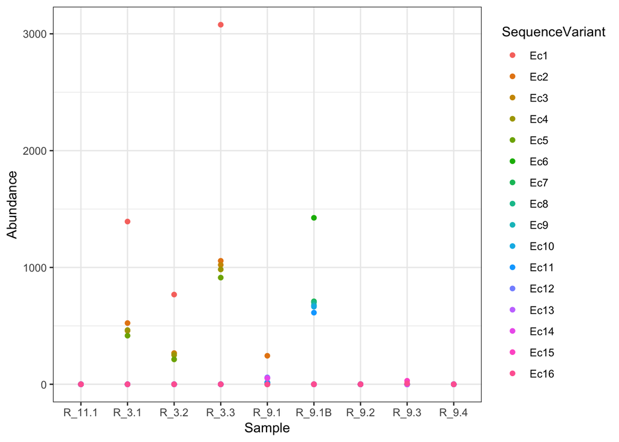

```r
ecdf <- data.frame(st2[,is.ecoli])
names(sqec) <- paste0("Ec", seq(ncol(ecdf)))
ecnames <- names(sqec); names(ecnames) <- sqec # map to ecnames from sequences
colnames(ecdf) <- names(sqec)
ecdf <- cbind(ecdf, Sample=rownames(st2))
ecm <- melt(ecdf, id.vars="Sample", value.name="Abundance", variable.name="SequenceVariant")
ggplot(data=ecm, aes(x=Sample, y=Abundance, color=SequenceVariant)) + geom_point()
```

Very clear 3:1:1:1:1 full complement signal in R_3, consistent over the time-course from R_3.1 to R_3.2 to R_3.3. R_9.1B also has a clear 2:1:1:1:1:1 full complement.

R_9.1 is less clear because fo the lower abundances, but may have 2 distinct strains given the 10 total *E. coli* variants in that sample (see previous code block). Note that R_9.1 precedes R_9.1B from the same subject. Taking a closer look at R_9.1:

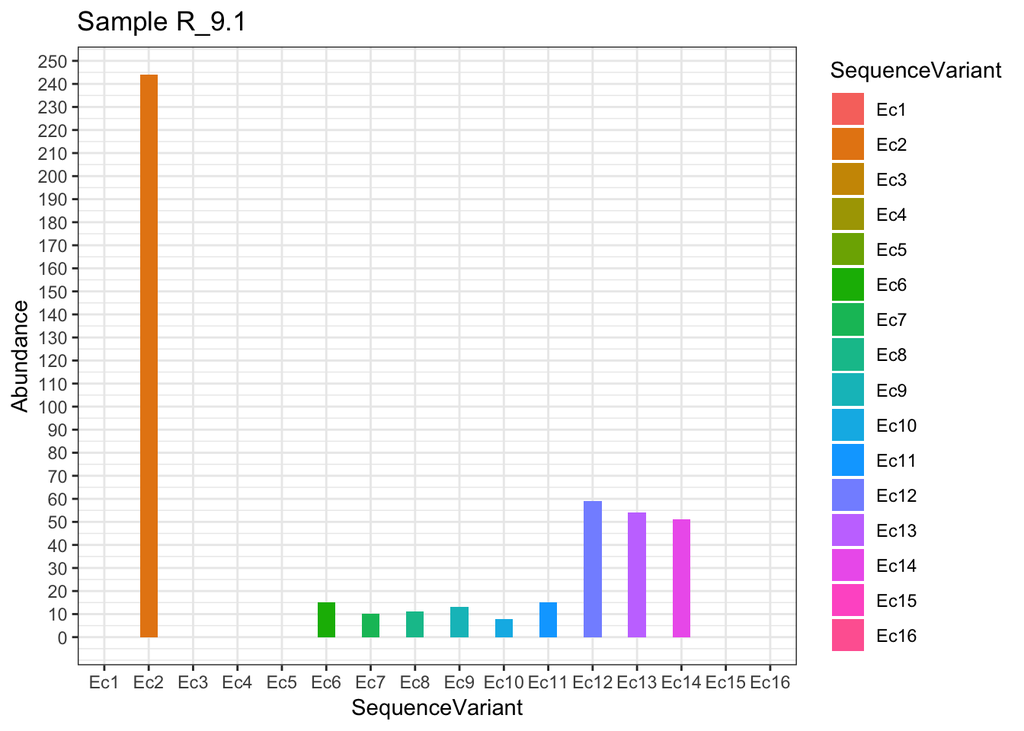

```r
isam <- "R_9.1"
ggplot(data=ecm[ecm$Sample == isam,], aes(x=SequenceVariant, y=Abundance, fill=SequenceVariant)) +
  geom_col(width=0.4) + scale_y_continuous(breaks=seq(0,250,10)) +
  ggtitle(paste("Sample", isam))
```

```r
ecdf["R_9.1B",]
```

```
##        Ec1 Ec2 Ec3 Ec4 Ec5  Ec6 Ec7 Ec8 Ec9 Ec10 Ec11 Ec12 Ec13 Ec14 Ec15
## R_9.1B   0   0   0   0   0 1425 710 700 677  664  613    0    0    0    0
##        Ec16 Sample
## R_9.1B    0 R_9.1B
```

Pretty cool that even when the minor variants are at an abundance of below 10 they are still being detected!

Make a publication plot of just samples with appreciable *E. coli* (and one extra sample from R9 to make both time-courses have 3 samples).

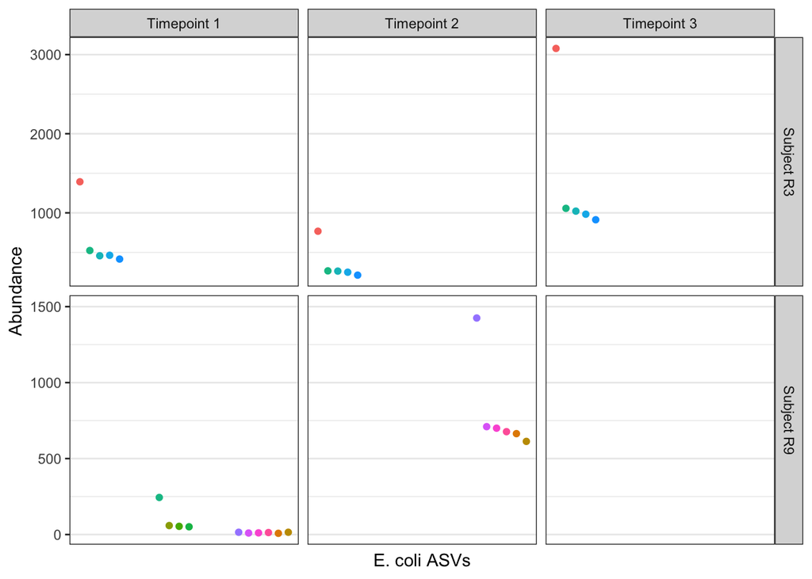

```r
ecm$SampleOrder <- df$SampleOrder[ecm$Sample]
ecm$Timepoint <- paste("Timepoint", ecm$SampleOrder)
ecm$Subject <- df$Subject[ecm$Sample]
ecm$SubjectLabel <- paste("Subject", df$Subject[ecm$Sample])
ecmp <- ecm[ecm$Sample %in% c("R_3.1", "R_3.2", "R_3.3", "R_9.1", "R_9.1B", "R_9.2"),]
ecmp$SequenceVariant <- as.character(ecmp$SequenceVariant)
ecmp <- ecmp[ecmp$Abundance > 0,]
xx.R3 <- c(Ec1=1, Ec2=2, Ec3=3, Ec4=4, Ec5=5) # Strain 1
PAD <- 8 # Between strain pad
xx.R9 <- c(Ec2=1+PAD, Ec12=2+PAD, Ec13=3+PAD, Ec14=4+PAD, # Strain 2
           Ec6=1+2*PAD, Ec7=2+2*PAD, Ec8=3+2*PAD, Ec9=4+2*PAD, Ec10=5+2*PAD, Ec11=6+2*PAD) # Strain 3
ecmp$X <- 0
is.R3 <- ecmp$Subject == "R3"; ecmp$X[is.R3] <- xx.R3[ecmp$SequenceVariant[is.R3]]
is.R9 <- ecmp$Subject == "R9"; ecmp$X[is.R9] <- xx.R9[ecmp$SequenceVariant[is.R9]]
# Force desired facet ymax limits with a custom data.frame
dflim <- data.frame(X=c(1, 1), Abundance=c(3000, 1500),
                    SequenceVariant=c("Ec1", "Ec1"),
                    SubjectLabel=c("Subject R3", "Subject R9"), Timepoint=c("Timepoint 1", "Timepoint 1"))
p.ecoli <- ggplot(data=ecmp, aes(x=X, y=Abundance, color=SequenceVariant)) + geom_point() +
  facet_grid(SubjectLabel~Timepoint, scales="free_y") +
  xlab("E. coli ASVs") + theme(axis.ticks.x=element_blank(), axis.text.x = element_blank()) +
  theme(panel.grid.major.x=element_blank(), panel.grid.minor.x=element_blank()) +
  geom_blank(data=dflim) +
  guides(color=FALSE)
p.ecoli
```

```r
ggsave(file.path(path.out, "Fecal_Ecoli_ASVs.pdf"), width=5, height=3, useDingbats=FALSE)
```

## Ordination

Create an ordination.

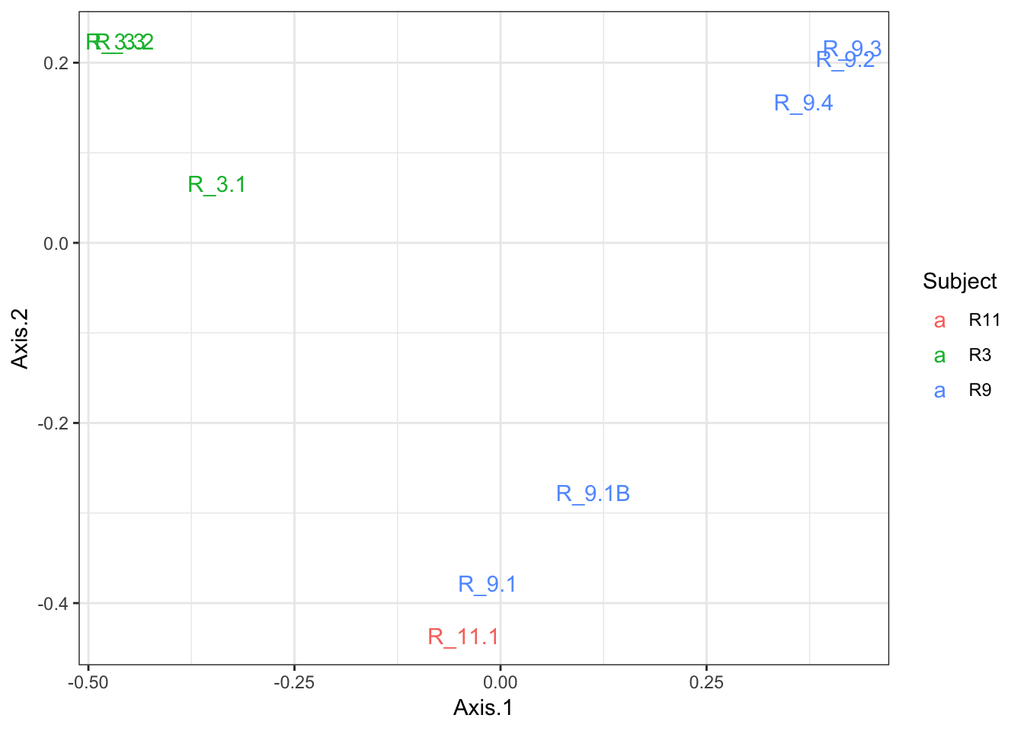

```r
ps2 <- phyloseq(otu_table(ft2, taxa_are_rows=FALSE), sample_data(df))
ord2 <- ordinate(ps2, method="MDS", distance="bray")
dford2 <- cbind(df, ord2$vectors)
ggplot(data=dford2, aes(x=Axis.1, y=Axis.2, color=Subject)) + geom_text(aes(label=SampleID))
```

These are just crude whole-community ordinations, but clearly there are strong time-course correlations, as the R3 samples and R9 2-4 cluster close together. The third cluster of points is everything else, which includes the two earlier R9 samples as well (R9 1 & 1B).

## TECHNICAL. REPLICATES.

Since we do not have a ground truth in these natural samples, we repeated the sequencing of these samples to create technical replicates, so as to characterize the consistency of our method. Note: These are close but not perfect technical replicates, as Replicate 1 was sequenced using the currently available S/P2-C2/5.0 sequencing chemistry, and Replicate 2 of the fecal samples was sequenced with a pre-release version of the S/P3-C3/5.0 sequencing chemistry.

We haven’t performed the pre-processing steps yet for the Replicate 1 samples, so we go ahead and do that now (primer removal, filtering, learn error rates).

```r
fns1 <- list.files(path1, pattern="fastq.gz", full.names=TRUE)
sample.names1 <- sapply(strsplit(fns1, "_"), function(x) paste(x[4], x[5], sep="_"))
sample.names1 <- gsub(".fastq.gz", "", sample.names1)
# Remove primers
nops1 <- file.path(path1, "noprimers", basename(fns1))
prim1 <- removePrimers(fns1, nops1, primer.fwd=F27, primer.rev=dada2:::rc(R1492), orient=TRUE)
# Filter
filts1 <- file.path(path1, "noprimers", "filtered", basename(fns1))
track1 <- filterAndTrim(nops1, filts1, minQ=3, minLen=1000, maxLen=1600, maxN=0, rm.phix=FALSE, maxEE=2)
track1
```

```
##                                        reads.in reads.out
## Callahan_16S_2pM-Cell1_R_11.1.fastq.gz    12955     10307
## Callahan_16S_2pM-Cell1_R_3.1.fastq.gz     18588     15043
## Callahan_16S_2pM-Cell1_R_3.2.fastq.gz     18663     14939
## Callahan_16S_2pM-Cell1_R_3.3.fastq.gz     11838      9447
## Callahan_16S_2pM-Cell1_R_9.1.fastq.gz     19923     16052
## Callahan_16S_2pM-Cell1_R_9.1B.fastq.gz    18362     14630
## Callahan_16S_2pM-Cell1_R_9.2.fastq.gz     15186     12158
## Callahan_16S_2pM-Cell1_R_9.3.fastq.gz     12641     10115
## Callahan_16S_2pM-Cell1_R_9.4.fastq.gz     10053      8117
```

Note that the read yield is lower in Replicate 1 than Replicate 2, because the new chemistry used in Replicate 2 has higher yield.

Continue through learning the error rates.

```r
err1 <- learnErrors(filts1, errorEstimationFunction=PacBioErrfun, BAND_SIZE=32, multithread=TRUE)
```

```
## 117435233 total bases in 80418 reads from 6 samples will be used for learning the error rates.
```

```r
saveRDS(err1, file.path(path.rds, "Fecal_err1.rds"))
```

And denoise for the read tracking counts.

```r
dd1 <- dada(filts1, err=err1, BAND_SIZE=32, multithread=TRUE)
```

```
## Sample 1 - 10307 reads in 3567 unique sequences.
## Sample 2 - 15043 reads in 3945 unique sequences.
## Sample 3 - 14939 reads in 4466 unique sequences.
## Sample 4 - 9447 reads in 2845 unique sequences.
## Sample 5 - 16052 reads in 4945 unique sequences.
## Sample 6 - 14630 reads in 4537 unique sequences.
## Sample 7 - 12158 reads in 4122 unique sequences.
## Sample 8 - 10115 reads in 3924 unique sequences.
## Sample 9 - 8117 reads in 3089 unique sequences.
```

Read tracking for Replicate 1:

```r
cbind(ccs=prim1[,1], primers=prim1[,2], filtered=track1[,2], denoised=sapply(dd1, function(x) sum(x$denoised)))
```

```
##                                          ccs primers filtered denoised
## Callahan_16S_2pM-Cell1_R_11.1.fastq.gz 16195   12955    10307    10212
## Callahan_16S_2pM-Cell1_R_3.1.fastq.gz  24657   18588    15043    14972
## Callahan_16S_2pM-Cell1_R_3.2.fastq.gz  22799   18663    14939    14772
## Callahan_16S_2pM-Cell1_R_3.3.fastq.gz  14675   11838     9447     9401
## Callahan_16S_2pM-Cell1_R_9.1.fastq.gz  25306   19923    16052    15935
## Callahan_16S_2pM-Cell1_R_9.1B.fastq.gz 23003   18362    14630    14443
## Callahan_16S_2pM-Cell1_R_9.2.fastq.gz  19073   15186    12158    11906
## Callahan_16S_2pM-Cell1_R_9.3.fastq.gz  16315   12641    10115     9735
## Callahan_16S_2pM-Cell1_R_9.4.fastq.gz  12438   10053     8117     7816
```

Check the total numbers for each replicate after primer removal and filtering.

```r
colSums(track1); median(track1[,2])
```

```
##  reads.in reads.out
##    138209    110808
```

```
## [1] 12158
```

```r
colSums(track2); median(track2[,2])
```

```
##  reads.in reads.out
##    192652    189614
```

```
## [1] 21411
```

## Rarefy to consistent depth

We now rarefy samples from each replicate down to a consistent read depth of 10,000 to remove systematic library size effects.

Set up file paths and define function.

```r
path1.rare <- file.path(dirname(filts1[[1]]), "Rare10K")
if(!dir.exists(path1.rare)) dir.create(path1.rare)
path2.rare <- file.path(dirname(filts2[[1]]), "Rare10K")
if(!dir.exists(path2.rare)) dir.create(path2.rare)
# Define function that rarefies fastq files
rarefyFastq <- function(filt, fout, n) {
  require(ShortRead)
  if(file.exists(fout)) file.remove(fout)
  f <- FastqSampler(filt, n=n)
  fq.sample <- yield(f)
  close(f)
  nout <- writeFastq(fq.sample, fout)
  nout
}
```

Rarefy the first replicate to 10k reads per sample.

```r
set.seed(100) # Seed RN generator for full replication
rares1 <- file.path(path1.rare, basename(filts1))
nrec1 <- mapply(rarefyFastq, filts1, rares1, n=10000)
names(nrec1) <- sample.names1
nrec1
```

```
## R_11.1  R_3.1  R_3.2  R_3.3  R_9.1 R_9.1B  R_9.2  R_9.3  R_9.4
##  10000  10000  10000   9447  10000  10000  10000  10000   8117
```

Two samples had less then 10k reads. While we could drop the rarefaction depth, I’m choosing to keep it at 10k and drop those samples for ease of interpretability (e.g. 1% frequency = 100 reads).

Rarefy the second replicate to 10k reads per sample.

```r
rares2 <- file.path(path2.rare, basename(filts2))
nrec2 <- mapply(rarefyFastq, filts2, rares2, n=10000)
names(nrec2) <- sample.names2
nrec2
```

```
## R_11.1  R_3.1  R_3.2  R_3.3  R_9.1 R_9.1B  R_9.2  R_9.3  R_9.4
##  10000  10000  10000  10000  10000  10000  10000  10000  10000
```

Pick out just the samples that reached 10k in both replicates.

```r
identical(sample.names1, sample.names2) # TRUE
```

```
## [1] TRUE
```

```r
sample.names <- sample.names1
keep <- nrec1 == 10000 & nrec2 == 10000
```

Now we go ahead and process the rarefied samples.

Replicate 1:

```r
drp1.rare <- derepFastq(rares1[keep])
dd1.rare <- dada(drp1.rare, err=err1, multithread=TRUE, BAND_SIZE=32)
```

```
## Sample 1 - 10000 reads in 3468 unique sequences.
## Sample 2 - 10000 reads in 2739 unique sequences.
## Sample 3 - 10000 reads in 3168 unique sequences.
## Sample 4 - 10000 reads in 3209 unique sequences.
## Sample 5 - 10000 reads in 3257 unique sequences.
## Sample 6 - 10000 reads in 3466 unique sequences.
## Sample 7 - 10000 reads in 3891 unique sequences.
```

```r
st1.rare <- makeSequenceTable(dd1.rare)
```

Replicate 2:

```r
drp2.rare <- derepFastq(rares2[keep])
dd2.rare <- dada(drp2.rare, err=err2, multithread=TRUE, BAND_SIZE=32)
```

```
## Sample 1 - 10000 reads in 2717 unique sequences.
## Sample 2 - 10000 reads in 2149 unique sequences.
## Sample 3 - 10000 reads in 2447 unique sequences.
## Sample 4 - 10000 reads in 2614 unique sequences.
## Sample 5 - 10000 reads in 2545 unique sequences.
## Sample 6 - 10000 reads in 2895 unique sequences.
## Sample 7 - 10000 reads in 3122 unique sequences.
```

```r
st2.rare <- makeSequenceTable(dd2.rare)
```

We now merge the sequence tables into a data.frame with entries for each ASV found in each sample (in either replicate) along with the abundances detected in both replicates.k

```r
sq1.rare <- colnames(st1.rare)
rownames(st1.rare) <- sample.names[keep]
df1 <- melt(st1.rare, varnames=c("Sample", "Sequence"), value.name="Abundance.1")
sq2.rare <- colnames(st2.rare)
rownames(st2.rare) <- sample.names[keep]
df2 <- melt(st2.rare, varnames=c("Sample", "Sequence"), value.name="Abundance.2")
df.rep <- merge(df1, df2, by=c("Sample", "Sequence"))
# Remove the sequence/samples in which that sequence wasn't in that sample
df.rep <- df.rep[df.rep$Abundance.1 > 0 | df.rep$Abundance.2 > 0,]
df.rep$Presence <- "Both"
df.rep$Presence[df.rep$Abundance.1>0 & df.rep$Abundance.2==0] <- "Replicate.1"
df.rep$Presence[df.rep$Abundance.1==0 & df.rep$Abundance.2>0] <- "Replicate.2"
```

Let’s visualize the agreement.

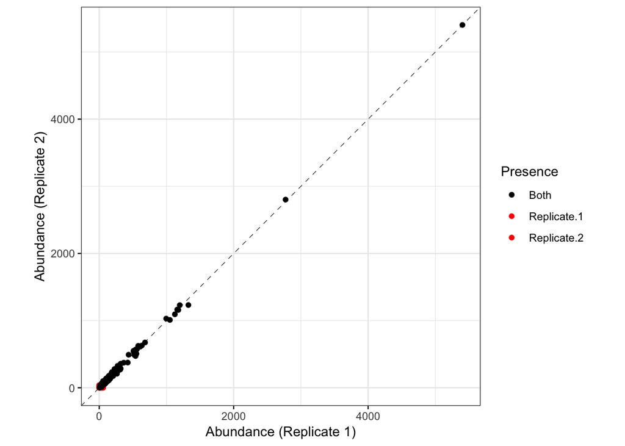

```r
p.rep <- ggplot(data=df.rep, aes(x=Abundance.1, y=Abundance.2, color=Presence)) +
  geom_point() + theme(aspect.ratio=1) +
  geom_abline(intercept=0, slope=1, linetype="dashed", size=0.2) +
  xlab("Abundance (Replicate 1)") + ylab("Abundance (Replicate 2)") +
  scale_color_manual(values=c(Both="black", Replicate.1="red", Replicate.2="red"))
p.rep
```

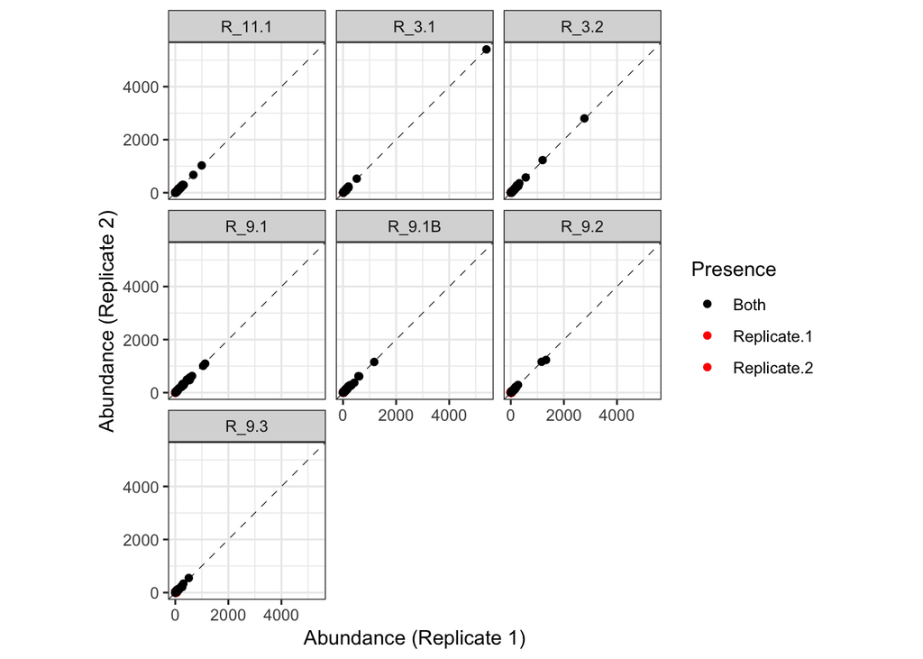

```r
p.rep + facet_wrap(~Sample)
```

That’s pretty good! Let’s take a closer look at the low abundance stuff.

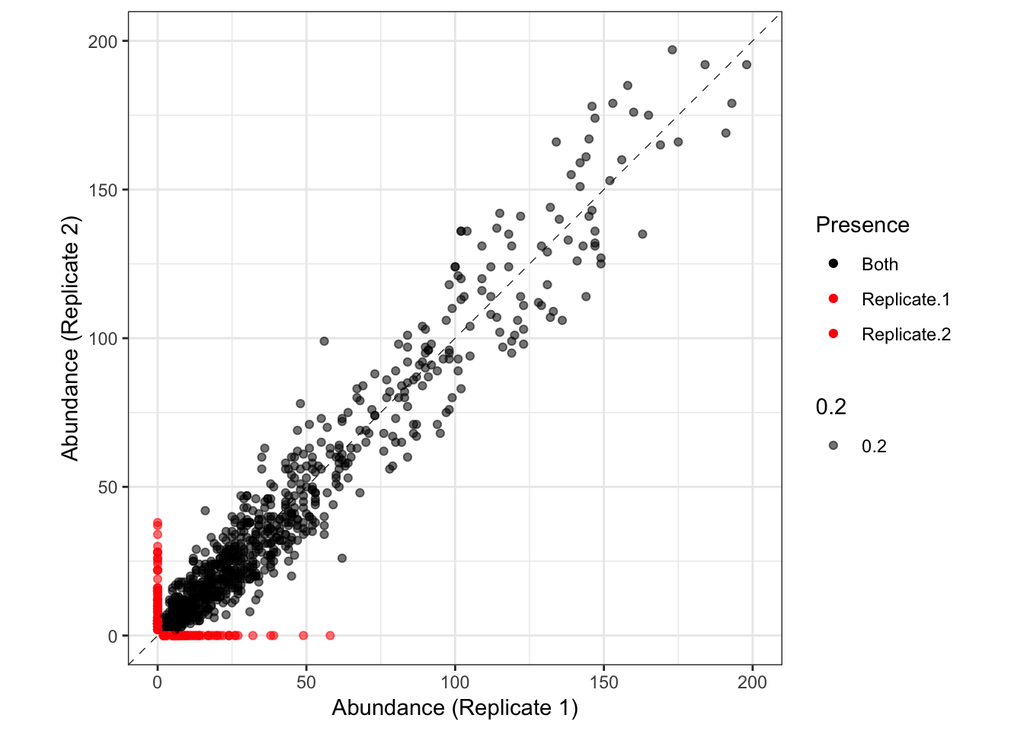

```r
p.rep + xlim(0,200) + ylim(0, 200) + aes(alpha=0.2)
```

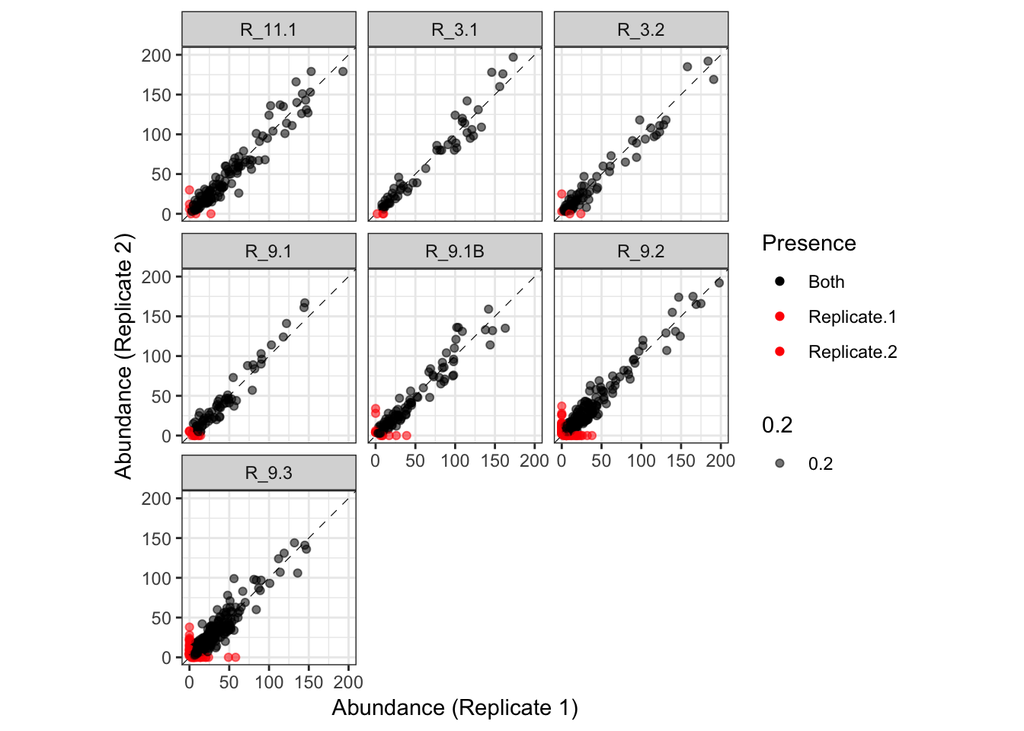

```r
p.rep + xlim(0,200) + ylim(0, 200) + aes(alpha=0.2) + facet_wrap(~Sample)
```

```r
cor(df.rep$Abundance.1, df.rep$Abundance.2)
```

```
## [1] 0.9982671
```

```r
table(df.rep$Presence)
```

```
##
##        Both Replicate.1 Replicate.2
##         881          65          70
```

```r
tapply(df.rep$Abundance.1, df.rep$Presence, sum)/sum(df.rep$Abundance.1)
```

```
##        Both Replicate.1 Replicate.2
##  0.98696081  0.01303919  0.00000000
```

```r
tapply(df.rep$Abundance.2, df.rep$Presence, sum)/sum(df.rep$Abundance.2)
```

```
##        Both Replicate.1 Replicate.2
##  0.98758465  0.00000000  0.01241535
```

Now make a publication plot showing the full range and the low-frequency range:

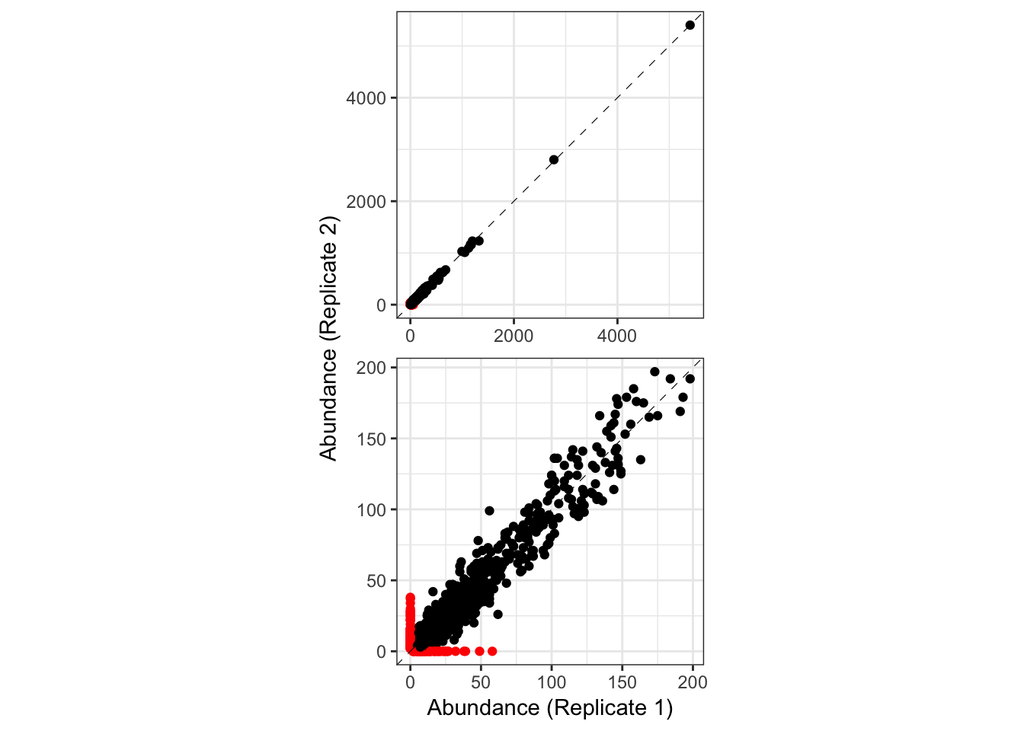

```r
df2B <- rbind(cbind(df.rep, Range="ALL"),
              cbind(df.rep[df.rep$Abundance.1 <= 200 & df.rep$Abundance.2 <= 200,], Range="LTE300"))
p2B <- ggplot(data=df2B, aes(x=Abundance.1, y=Abundance.2, color=Presence)) +
  geom_point() + theme(aspect.ratio=1) +
  geom_abline(intercept=0, slope=1, linetype="dashed", size=0.2) +
  xlab("Abundance (Replicate 1)") + ylab("Abundance (Replicate 2)") +
  scale_color_manual(values=c(Both="black", Replicate.1="red", Replicate.2="red")) +
  facet_wrap(~Range, scales="free", ncol=1) + theme(strip.text=element_blank()) +
  guides(color=FALSE)
p2B
```

```r
ggsave(file.path(path.out, "Fecal_Replicate_Cor.pdf"), p2B, width=3, height=5,units="in", useDingbats=FALSE)
```

And a publication plot with both panels:

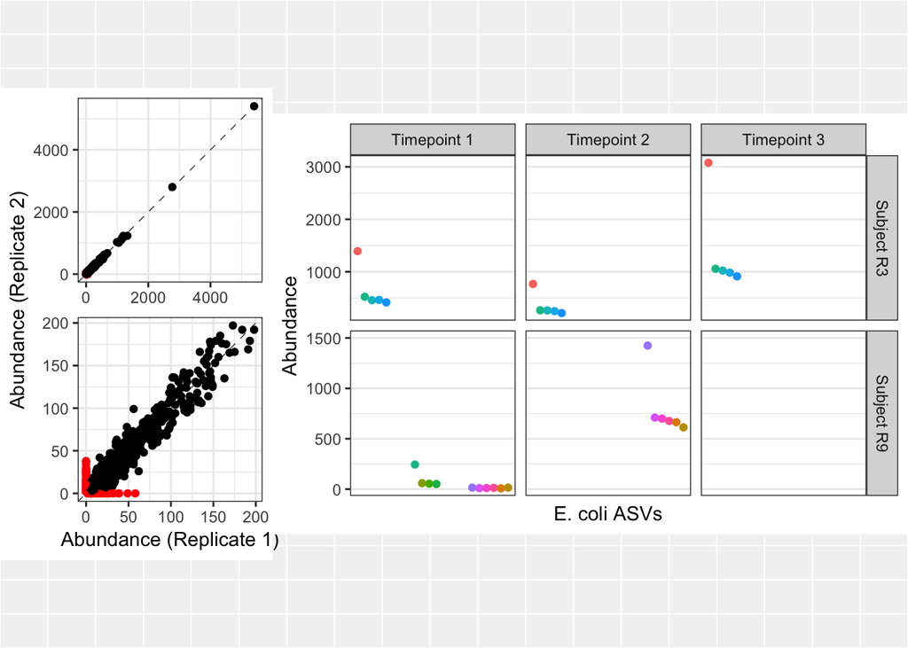

```r
p.2pan <- arrangeGrob(p2B, p.ecoli + theme(aspect.ratio=1), nrow=1, widths=c(0.3, 0.7))
plot(p.2pan)
```

```r
ggsave(file.path(path.out, "Fecal_2Panel.pdf"), p.2pan,
                 width=178, height=88, units="mm", useDingbats=FALSE)
# Finish up the strain labeling and panel labels in Illustrator
```